# Practical Machine Learning Assignment

### Coursera Data Science Specialization

### Practical Machining Learning Module

### Project Assignment

#### 1. Background

Using devices such as Jawbone Up, Nike FuelBand, and Fitbit it is now possible to collect a large amount of data about personal activity relatively inexpensively. These type of devices are part of the quantified self movement - a group of enthusiasts who take measurements about themselves regularly to improve their health, to find patterns in their behavior, or because they are tech geeks. One thing that people regularly do is quantify how much of a particular activity they do, but they rarely quantify how well they do it. In this project, your goal will be to use data from accelerometers on the belt, forearm, arm, and dumbell of 6 participants. They were asked to perform barbell lifts correctly and incorrectly in 5 different ways. More information is available from the website here: http://groupware.les.inf.puc-rio.br/har (see the section on the Weight Lifting Exercise Dataset).

#### 2. Data

The training data for this project are available here: https://d396qusza40orc.cloudfront.net/predmachlearn/pml-training.csv

The test data are available here: https://d396qusza40orc.cloudfront.net/predmachlearn/pml-testing.csv

The data for this project come from this source: http://groupware.les.inf.puc-rio.br/har

#### 3. Load required packages for analysis

```r
library(caret)
```

```r
library(rpart)
library(ggplot2)
library(corrplot)
library(randomForest)
library(rattle)
set.seed(12345)
```

#### 4. Load data

```r
training_raw <- read.csv("pml-training.csv")[,-1]
testing <- read.csv("pml-testing.csv")[,-1]
# check dimension of the training and test dataset
dim(training_raw)
```

```
## [1] 19622   159
```

```r
dim(testing)
```

```
## [1]  20 159
```

#### 5. Clean data

```r
# remove predictors that have many missing/NA values or non-unique values
NZV <- nearZeroVar(training_raw)
training <- training_raw[, -NZV]
testing <- testing[, -NZV]

# remove cases that have many missing/NA values
NaValues <- sapply(training, function(x) mean(is.na(x))) > 0.9
training <- training[, NaValues == "FALSE"]
testing <- testing[, NaValues == "FALSE"]

# remove id and time variables
training <- training[,-c(1:5)]
testing <- testing[,-c(1:5)]

# check dimension of the cleaned up dataset
dim(training)
```

```
## [1] 19622    53
```

```r
dim(testing)
```

```
## [1] 20 53
```

```r
# take a look at the training dataset
head(training)
```

```
##   roll_belt pitch_belt yaw_belt total_accel_belt gyros_belt_x gyros_belt_y
## 1      1.41       8.07    -94.4                3         0.00         0.00
## 2      1.41       8.07    -94.4                3         0.02         0.00
## 3      1.42       8.07    -94.4                3         0.00         0.00
## 4      1.48       8.05    -94.4                3         0.02         0.00
## 5      1.48       8.07    -94.4                3         0.02         0.02
## 6      1.45       8.06    -94.4                3         0.02         0.00
##   gyros_belt_z accel_belt_x accel_belt_y accel_belt_z magnet_belt_x
## 1        -0.02          -21            4           22            -3
## 2        -0.02          -22            4           22            -7
## 3        -0.02          -20            5           23            -2
## 4        -0.03          -22            3           21            -6
## 5        -0.02          -21            2           24            -6
## 6        -0.02          -21            4           21             0
##   magnet_belt_y magnet_belt_z roll_arm pitch_arm yaw_arm total_accel_arm
```

[output cut: 69 more lines]

#### 6. Prepare data partition, for later validation

```r
inTrain <- createDataPartition(y= training$classe, p = 0.7, list = FALSE)
training <- training[inTrain, ]
crossvalidation <- training[-inTrain, ]
```

```r
# decision trees
model_tree <- train(classe~., data = training, method = "rpart")
# print result of model prediction on original training and crossvalidation dataset
predict_training_tree <- predict(model_tree, training)
confusionmatrix_training_tree <- confusionMatrix(predict_training_tree, training$classe)

predict_crossvalidation_tree <- predict(model_tree, crossvalidation)
confusionmatrix_cv_tree <- confusionMatrix(predict_crossvalidation_tree, crossvalidation$classe)

print(confusionmatrix_cv_tree)
```

```
## Confusion Matrix and Statistics
##
##           Reference
## Prediction    A    B    C    D    E
##          A 1074  319  345  319  100
##          B   11  276   20  128   91
##          C   67  207  354  259  205
##          D    0    0    0    0    0
##          E    9    0    0    0  326
##
## Overall Statistics
##
##                Accuracy : 0.4939
##                  95% CI : (0.4785, 0.5093)
##     No Information Rate : 0.2825
##     P-Value [Acc > NIR] : < 2.2e-16
##
##                   Kappa : 0.3393
##  Mcnemar's Test P-Value : NA
##
## Statistics by Class:
##
##                      Class: A Class: B Class: C Class: D Class: E
## Sensitivity            0.9251  0.34414  0.49235   0.0000  0.45152
## Specificity            0.6328  0.92443  0.78237   1.0000  0.99734
## Pos Pred Value         0.4979  0.52471  0.32418      NaN  0.97313
## Neg Pred Value         0.9555  0.85324  0.87906   0.8282  0.89510
## Prevalence             0.2825  0.19513  0.17494   0.1718  0.17567
## Detection Rate         0.2613  0.06715  0.08613   0.0000  0.07932
## Detection Prevalence   0.5248  0.12798  0.26569   0.0000  0.08151
## Balanced Accuracy      0.7789  0.63428  0.63736   0.5000  0.72443
```

```r
# random forest
model_rf <- train(classe~., data = training, method = "rf")
# print result of model prediction on original training and crossvalidation dataset
predict_training_rf <- predict(model_rf, training)
confusionmatrix_training_rf <- confusionMatrix(predict_training_rf, training$classe)

predict_crossvalidation_rf <- predict(model_rf, crossvalidation)
confusionmatrix_cv_rf <- confusionMatrix(predict_crossvalidation_rf, crossvalidation$classe)

print(confusionmatrix_cv_rf)
```

```
## Confusion Matrix and Statistics
##
##           Reference
## Prediction    A    B    C    D    E
##          A 1161    0    0    0    0
##          B    0  802    0    0    0
##          C    0    0  719    0    0
##          D    0    0    0  706    0
##          E    0    0    0    0  722
##
## Overall Statistics
##
##                Accuracy : 1
##                  95% CI : (0.9991, 1)
##     No Information Rate : 0.2825
##     P-Value [Acc > NIR] : < 2.2e-16
##
##                   Kappa : 1
##  Mcnemar's Test P-Value : NA
##
## Statistics by Class:
##
##                      Class: A Class: B Class: C Class: D Class: E
## Sensitivity            1.0000   1.0000   1.0000   1.0000   1.0000
## Specificity            1.0000   1.0000   1.0000   1.0000   1.0000
## Pos Pred Value         1.0000   1.0000   1.0000   1.0000   1.0000
## Neg Pred Value         1.0000   1.0000   1.0000   1.0000   1.0000
## Prevalence             0.2825   0.1951   0.1749   0.1718   0.1757
## Detection Rate         0.2825   0.1951   0.1749   0.1718   0.1757
## Detection Prevalence   0.2825   0.1951   0.1749   0.1718   0.1757
## Balanced Accuracy      1.0000   1.0000   1.0000   1.0000   1.0000
```

#### 8. Conclusion

The confusionmatrix showed that the accuracy of the random forest models is better than the decision tree model. Therefore, we used this model to predict on the testing dataset.

#### 9. Predict on testing dataset

```r
predict_testing <- predict(model_rf, testing)
predict_testing
```

```
##  [1] B A B A A E D B A A B C B A E E A B B B
## Levels: A B C D E
```

#### 10. Appendix

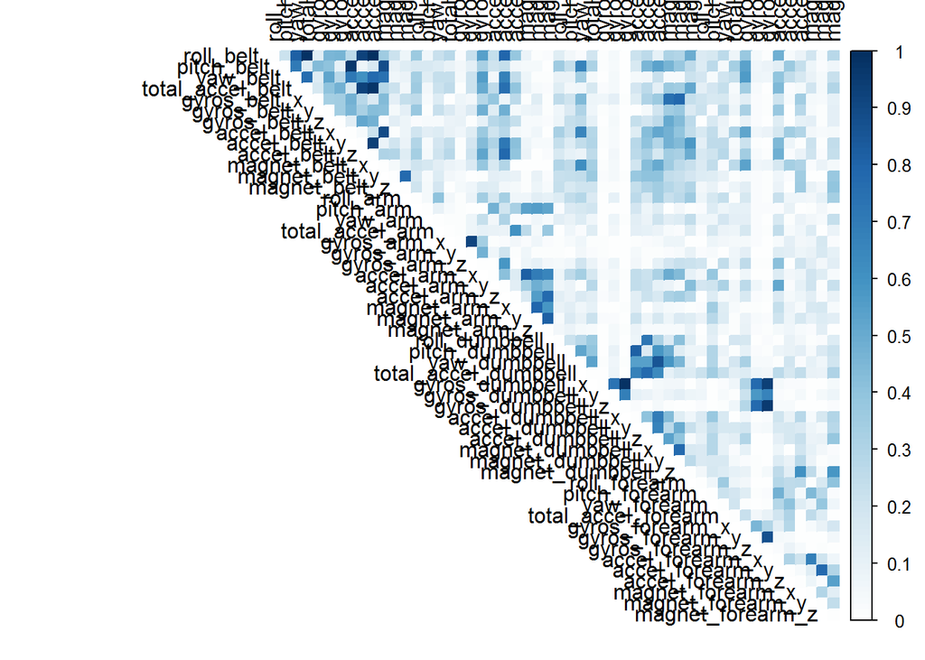

```r
# explore the remianing predictors
# check the factor variables
predictor_factor <- which(sapply(training, class) == "factor")
# explore correlation between predictors
predictor_cor <- abs(cor(training[,-predictor_factor]))
# turn lower tri to 0
predictor_cor[lower.tri(predictor_cor, diag = TRUE)] <- 0
# visualize result
corrplot(predictor_cor, method  = "color", type = "upper", cl.lim = c(0,1), tl.col = rgb(0, 0, 0))
```

```r
# find highly correlated predictors
which(predictor_cor > 0.8, arr.ind = TRUE)
```

```
##                  row col
## roll_belt          1   3
## roll_belt          1   4
## pitch_belt         2   8
## roll_belt          1   9
## total_accel_belt   4   9
## roll_belt          1  10
## total_accel_belt   4  10
## accel_belt_y       9  10
## pitch_belt         2  11
## accel_belt_x       8  11
## gyros_arm_x       18  19
## accel_arm_x       21  24
## magnet_arm_y      25  26
## gyros_dumbbell_x  31  33
## pitch_dumbbell    28  34
## yaw_dumbbell      29  36
## gyros_dumbbell_x  31  46
## gyros_dumbbell_z  33  46
## gyros_forearm_y   45  46
```

```r
# Therefore, there are highly correlated predictors, principal component analysis is necessary.
```